# Data Pre-procssing

# Setup

```r
library(tidyverse)
library(AppliedPredictiveModeling)
data("segmentationOriginal")
```

# Analysis

Filter training set samples

```r
segData <- segmentationOriginal %>%
  tbl_df() %>%
  filter(Case == "Train")
```

Save `Class`, `Cell` fields into seperate vectors, and remove from main object

```r
cellID <- segData %>% select(Cell)
class <- segData %>% select(Class)
case <- segData %>% select(Case)
# Remove columns
segData <- segData %>%
  select(-c(Cell, Class, Case))
```

The original data contained several “status” columns which were binary versions of the predictors. To remove these, we find the column names containing “Status” and remove them

```r
statusColNum <- grep("Status", names(segData))
print(statusColNum)
```

```
 [1]   2   4   9  10  11  12  14  16  20  21  22  26  27  28  30  32  34  36  38  40  43  44  46  48  51
[26]  52  55  56  59  60  63  64  68  69  70  72  73  74  76  78  80  82  84  86  88  92  93  94  97  98
[51] 103 104 105 106 110 111 112 114
```

```r
segData <- segData %>%
  select(-statusColNum)
```

## Transformations

Calculate sample skewness statistic for each predictor

```r
library(e1071)
# For one predictor
skewness(segData$AngleCh1)
```

```
[1] -0.02426252
```

```r
skewValues <- apply(segData, 2, skewness)
head(skewValues)
```

```
   AngleCh1     AreaCh1 AvgIntenCh1 AvgIntenCh2 AvgIntenCh3 AvgIntenCh4
-0.02426252  3.52510745  2.95918524  0.84816033  2.20234214  1.90047128
```

Using these values as a guide, the variables can be prioritized for visualizing the distribution

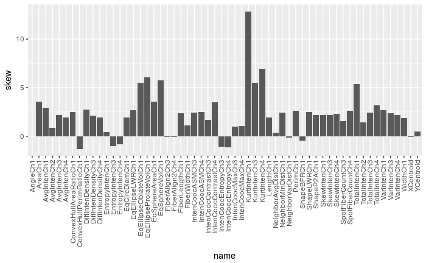

```r
tibble(name = names(skewValues), skew = skewValues) %>%
  ggplot(aes(x = name, y = skew)) + geom_bar(stat = "identity") + theme(axis.text.x = element_text(angle=90, hjust=1, vjust=.5))
```

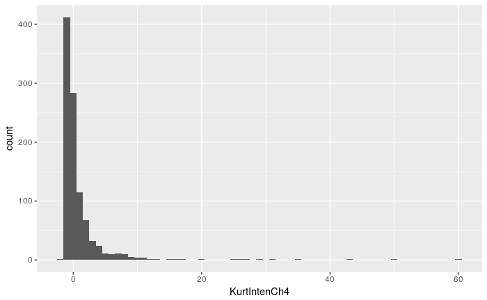

```r
ggplot(segData, aes(x = KurtIntenCh4)) + geom_histogram(binwidth = 1)
```

Estimate $lambda$ for Box Cox transformation using caret

```r
library(caret)
Ch1AreaTrans <- BoxCoxTrans(segData$AreaCh1)
Ch1AreaTrans
```

```
Box-Cox Transformation

1009 data points used to estimate Lambda

Input data summary:
   Min. 1st Qu.  Median    Mean 3rd Qu.    Max.
  150.0   194.0   256.0   325.1   376.0  2186.0

Largest/Smallest: 14.6
Sample Skewness: 3.53

Estimated Lambda: -0.9
```

```r
# original data
head(segData$AreaCh1)
```

```
[1] 819 431 298 256 258 358
```

```r
# after transformation
predict(Ch1AreaTrans, head(segData$AreaCh1))
```

```
[1] 1.108458 1.106383 1.104520 1.103554 1.103607 1.105523
```

```r
(819^(-.9) - 1)/(-.9)
```

```
[1] 1.108458
```

We can use base function `prcomp` for PCA

```r
# centering and scaling prior to PCA
pcaObject <- prcomp(segData, center = TRUE, scale. = TRUE)
#Calculate the cumulative percentage of variance which each component accounts for.
percentVariance <- pcaObject$sd^2/sum(pcaObject$sd^2)*100
percentVariance[1:3]
```

```
[1] 20.91236 17.01330 11.88689
```

Transformed values

```r
head(pcaObject$x[, 1:5])
```

```
            PC1        PC2         PC3       PC4        PC5
[1,]  5.0985749  4.5513804 -0.03345155 -2.640339  1.2783212
[2,] -0.2546261  1.1980326 -1.02059569 -3.731079  0.9994635
[3,]  1.2928941 -1.8639348 -1.25110461 -2.414857 -1.4914838
[4,] -1.4646613 -1.5658327  0.46962088 -3.388716 -0.3302324
[5,] -0.8762771 -1.2790055 -1.33794261 -3.516794  0.3936099
[6,] -0.8615416 -0.3286842 -0.15546723 -2.206636  1.4731658
```

Variable loadings

```r
head(pcaObject$rotation[, 1:3])
```

```
                     PC1         PC2          PC3
AngleCh1     0.001213758 -0.01284461  0.006816473
AreaCh1      0.229171873  0.16061734  0.089811727
AvgIntenCh1 -0.102708778  0.17971332  0.067696745
AvgIntenCh2 -0.154828672  0.16376018  0.073534399
AvgIntenCh3 -0.058042158  0.11197704 -0.185473286
AvgIntenCh4 -0.117343465  0.21039086 -0.105060977
```

Box–Cox transform, center, and scale the data, then execute PCA for signal extraction

```r
trans <- preProcess(as.data.frame(segData), method = c("BoxCox", "center", "scale", "pca"))
trans
```

```
Created from 1009 samples and 58 variables

Pre-processing:
  - Box-Cox transformation (47)
  - centered (58)
  - ignored (0)
  - principal component signal extraction (58)
  - scaled (58)

Lambda estimates for Box-Cox transformation:
    Min.  1st Qu.   Median     Mean  3rd Qu.     Max.
-2.00000 -0.50000 -0.10000  0.05106  0.30000  2.00000

PCA needed 19 components to capture 95 percent of the variance
```

```r
# apply transformation
transformed <- predict(trans, as.data.frame(segData))
head(transformed[, 1:5])
```

|  | PC1 | PC2 | PC3 | PC4 | PC5 |
| --- | --- | --- | --- | --- | --- |
| 1 | 1.5684742 | 6.2907855 | -0.3333299 | -3.063327 | -1.3415782 |
| 2 | -0.6664055 | 2.0455375 | -1.4416841 | -4.701183 | -1.7422020 |
| 3 | 3.7500055 | -0.3915610 | -0.6690260 | -4.020753 | 1.7927777 |
| 4 | 0.3768509 | -2.1897554 | 1.4380167 | -5.327116 | -0.4066757 |
| 5 | 1.0644951 | -1.4646516 | -0.9900478 | -5.627351 | -0.8650174 |
| 6 | -0.3798629 | 0.2173028 | 0.4387980 | -2.069880 | -1.9363920 |

## Filtering

Filtering near-zero variance preictors

```r
nearZeroVar(segData)
```

```
integer(0)
```

No columns with near-zero predictors

Filter on between-predictor correlations

```r
correlations <- cor(segData)
dim(correlations)
```

```
[1] 58 58
```

```r
correlations[1:4, 1:4]
```

```
                AngleCh1      AreaCh1 AvgIntenCh1 AvgIntenCh2
AngleCh1     1.000000000 -0.002627172 -0.04300776 -0.01944681
AreaCh1     -0.002627172  1.000000000 -0.02529739 -0.15330301
AvgIntenCh1 -0.043007757 -0.025297394  1.00000000  0.52521711
AvgIntenCh2 -0.019446810 -0.153303007  0.52521711  1.00000000
```

Examine the correlation structure of the data

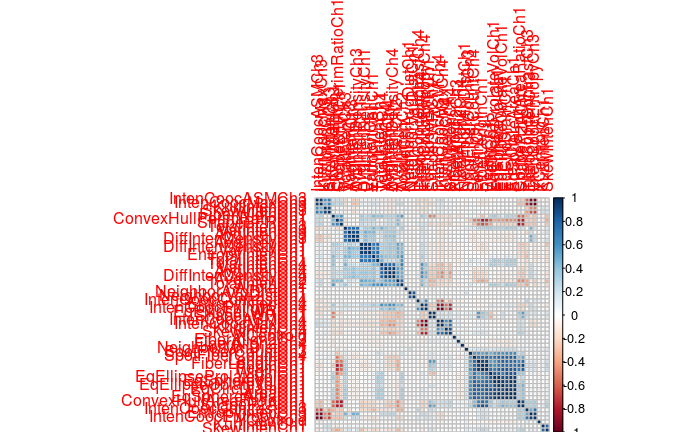

```r
library(corrplot)
# reorder to reveal clusters of highly correlated predictors
corrplot(correlations, order = "hclust")
```

Filter based on correlations; return column numbers denoting predictors recommended for deletion

```r
highcorr <- findCorrelation(correlations, cutoff = .75)
length(highcorr)
```

```
[1] 32
```

```r
head(highcorr)
```

```
[1] 23 40 43 36  7 15
```

```r
filteredSegData <- segData[, -highcorr]
```

## Creating dummy variables

Car dataset from `caret` package

```r
data("cars")
head(cars)
```

|  | Price | Mileage | Cylinder | Doors | Cruise | Sound | Leather | Buick | Cadillac | Chevy | Pontiac | Saab | Saturn | convertible | coupe | hatchback | sedan | wagon |
| --- | --- | --- | --- | --- | --- | --- | --- | --- | --- | --- | --- | --- | --- | --- | --- | --- | --- | --- |
| 1 | 22661.05 | 20105 | 6 | 4 | 1 | 0 | 0 | 1 | 0 | 0 | 0 | 0 | 0 | 0 | 0 | 0 | 1 | 0 |
| 2 | 21725.01 | 13457 | 6 | 2 | 1 | 1 | 0 | 0 | 0 | 1 | 0 | 0 | 0 | 0 | 1 | 0 | 0 | 0 |
| 3 | 29142.71 | 31655 | 4 | 2 | 1 | 1 | 1 | 0 | 0 | 0 | 0 | 1 | 0 | 1 | 0 | 0 | 0 | 0 |
| 4 | 30731.94 | 22479 | 4 | 2 | 1 | 0 | 0 | 0 | 0 | 0 | 0 | 1 | 0 | 1 | 0 | 0 | 0 | 0 |
| 5 | 33358.77 | 17590 | 4 | 2 | 1 | 1 | 1 | 0 | 0 | 0 | 0 | 1 | 0 | 1 | 0 | 0 | 0 | 0 |
| 6 | 30315.17 | 23635 | 4 | 2 | 1 | 0 | 0 | 0 | 0 | 0 | 0 | 1 | 0 | 1 | 0 | 0 | 0 | 0 |

Focus on price, mileage, car type

```r
carSubset <- cars %>%
  gather(key = Type, value = count, ... = -(1:7)) %>%
  filter(count >= 1) %>%
  select(Price, Mileage, Type)
head(carSubset)
```

|  | Price | Mileage | Type |
| --- | --- | --- | --- |
| 1 | 22661.05 | 20105 | Buick |
| 2 | 17750.88 | 25040 | Buick |
| 3 | 18145.13 | 18339 | Buick |
| 4 | 17772.97 | 25052 | Buick |
| 5 | 18348.90 | 23852 | Buick |
| 6 | 17394.02 | 25464 | Buick |

```r
carSubset$Type <- as.factor(carSubset$Type)
levels(carSubset$Type)
```

```
 [1] "Buick"       "Cadillac"    "Chevy"       "convertible" "coupe"       "hatchback"
 [7] "Pontiac"     "Saab"        "Saturn"      "sedan"       "wagon"
```

Create dummy variables

```r
simpleMod <- dummyVars(~Mileage + Type,
                       data = carSubset,
                       ## Remove the variable name from the column name
                       levelsOnly = TRUE)
simpleMod
```

```
Dummy Variable Object

Formula: ~Mileage + Type
2 variables, 1 factors
Factor variable names will be removed
A less than full rank encoding is used
```

generate the dummy variables for the training set or any new samples

```r
predict(simpleMod, head(carSubset))
```

```
  Mileage Buick Cadillac Chevy convertible coupe hatchback Pontiac Saab Saturn sedan wagon
1   20105     1        0     0           0     0         0       0    0      0     0     0
2   25040     1        0     0           0     0         0       0    0      0     0     0
3   18339     1        0     0           0     0         0       0    0      0     0     0
4   25052     1        0     0           0     0         0       0    0      0     0     0
5   23852     1        0     0           0     0         0       0    0      0     0     0
6   25464     1        0     0           0     0         0       0    0      0     0     0
```

Generate dummy variables with interaction between Mileage and Type

```r
withInteraction <- dummyVars(~Mileage + Type + Mileage:Type,
                             data = carSubset,
                             levelsOnly = TRUE)
withInteraction
```

```
Dummy Variable Object

Formula: ~Mileage + Type + Mileage:Type
2 variables, 1 factors
Factor variable names will be removed
A less than full rank encoding is used
```

```r
predict(withInteraction, head(carSubset))
```

```
  Mileage Buick Cadillac Chevy convertible coupe hatchback Pontiac Saab Saturn sedan wagon
1   20105     1        0     0           0     0         0       0    0      0     0     0
2   25040     1        0     0           0     0         0       0    0      0     0     0
3   18339     1        0     0           0     0         0       0    0      0     0     0
4   25052     1        0     0           0     0         0       0    0      0     0     0
5   23852     1        0     0           0     0         0       0    0      0     0     0
6   25464     1        0     0           0     0         0       0    0      0     0     0
  Mileage:Buick Mileage:Cadillac Mileage:Chevy Mileage:convertible Mileage:coupe Mileage:hatchback
1         20105                0             0                   0             0                 0
2         25040                0             0                   0             0                 0
3         18339                0             0                   0             0                 0
4         25052                0             0                   0             0                 0
5         23852                0             0                   0             0                 0
6         25464                0             0                   0             0                 0
  Mileage:Pontiac Mileage:Saab Mileage:Saturn Mileage:sedan Mileage:wagon
1               0            0              0             0             0
2               0            0              0             0             0
3               0            0              0             0             0
4               0            0              0             0             0
5               0            0              0             0             0
6               0            0              0             0             0
```